# 순환 신경망

## 순환 신경망(Recurrent Neural Network, RNN)

- RNN(Recurrent Neural Network)은 입력과 출력을 시퀀스 단위로 처리하는 시퀀스(Sequence) 모델
- 피드 포워드 신경망(Feed Forward Neural Network) : 은닉층에서 활성화 함수를 지난 값은 오직 출력층 방향으로만 향함
- RNN(Recurrent Neural Network) : **은닉층의 노드에서 활성화 함수를 통해 나온 결과값을 출력층 방향으로도 보내면서, 다시 은닉층 노드의 다음 계산의 입력으로 보내는 특징**
- $x$는 입력층의 입력 벡터, $y$는 출력층의 출력 벡터입니다. (실제로는 편향$b$도 입력으로 존재)
- **RNN에서 은닉층에서 활성화 함수를 통해 결과를 내보내는 역할을 하는 노드를 셀(cell)**
  - **셀은 이전의 값을 기억하려고 하는 일종의 메모리 역할을 수행**
- **은닉층의 메모리 셀은, 각각의 시점(time step)에서 바로 이전 시점에서의 은닉층의 메모리 셀에서 나온 값을 자신의 입력으로 사용하는 재귀적 활동 (현재 시점을 변수 $t$)**
- 현재 시점 t에서의 메모리 셀이 갖고있는 값은 과거의 메모리 셀들의 값에 영향을 받은 것
- 메모리 셀이 출력층 방향 또는 다음 시점인 t+1의 자신에게 보내는 값을 은닉 상태(hidden state)
- **t 시점의 메모리 셀은 t-1 시점의 메모리 셀이 보낸 은닉 상태값을 t 시점의 은닉 상태 계산을 위한 입력값으로 사용**

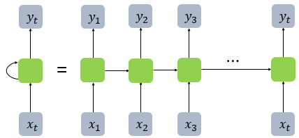

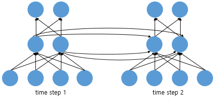

- RNN은 입력과 출력의 길이를 다르게 설계 할 수 있으므로 다양한 용도로 사용가능
- **RNN 셀의 각 시점의 입, 출력의 단위는 사용자가 정의하기 나름이지만 가장 보편적인 단위는 '단어 벡터'**
  - 하나의 입력에 대해서 여러개의 출력을 의미하는 일 대 다(one-to-many) 구조의 모델은 하나의 이미지 입력에 대해서 사진의 제목을 출력하는 이미지 캡셔닝(Image Captioning) 작업에 사용. 사진의 제목은 단어들의 나열이므로 시퀀스 출력
  - 단어 시퀀스에 대해서 하나의 출력을 하는 다 대 일(many-to-one) 구조의 모델은 입력 문서가 긍정적인지 부정적인지를 판별하는 감성 분류(sentiment classification), 또는 메일이 정상 메일인지 스팸 메일인지 판별하는 스팸 메일 분류(spam detection) 등에 사용
  - - 다 대 다(many-to-many) 구조의 모델의 경우에는 사용자가 문장을 입력하면 대답 문장을 출력하는 챗봇과 입력 문장으로부터 번역된 문장을 출력하는 번역기, 또는 '태깅 작업' 챕터에서 배우는 개체명 인식이나 품사 태깅과 같은 작업

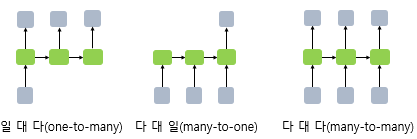

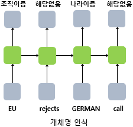

### RNN 수식

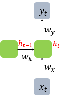

- 배치 크기가 1이고, $d$와 $D_h$ 두 값 모두를 4로 가정하였을 때, RNN의 은닉층 연산

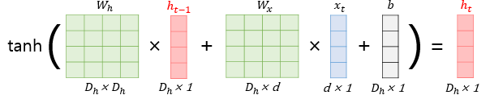

- 이때 $h_t$를 계산하기 위한 활성화 함수로는 주로 하이퍼볼릭탄젠트 함수(tanh)가 사용됩니다. 위의 식에서 각각의 가중치 $W_x$, $W_h$, $W_y$,의 값은 하나의 층에서는 모든 시점에서 값을 동일하게 공유
- 하지만 은닉층이 2개 이상일 경우에는 각 은닉층에서의 가중치는 서로 다름
- 출력층은 결과값인 $y_t$를 계산하기 위한 활성화 함수로는 푸는 문제에 따라서 다름
- 이진 분류를 해야하는 경우라면 출력층에 로지스틱 회귀를 사용하여 시그모이드 함수를 사용할 수 있고, 다중 클래스 분류를 해야하는 경우라면 출력층에 소프트맥스 회귀를 사용

## RNN 구현

```python
from tensorflow.keras.layers import SimpleRNN
from tensorflow.keras.models import Sequential
from tensorflow.keras.layers import SimpleRNN

import numpy as np
```

#### `tensorflow.keras.layers.SimpleRNN(hidden_units, timesteps, input_dim)`

- **`hidden_units`** : 은닉 상태의 크기를 정의. **메모리 셀이 다음 시점의 메모리 셀과 출력층으로 보내는 값의 크기(output_dim)와도 동일**.
  - RNN의 용량(capacity)을 늘린다고 보면 되며,
  - 중소형 모델의 경우 보통 128, 256, 512, 1024 등의 값
- `timesteps` : 입력 시퀀스의 길이(input_length). **시점의 수.**
- `input_dim` : 입력의 크기

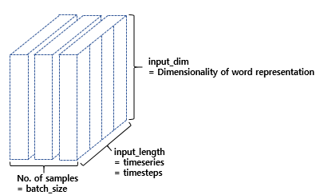

- RNN 층은 (batch_size, timesteps, input_dim) 크기의 3D 텐서를 입력으로 받음
- `batch_size는` 한 번에 학습하는 데이터의 개수
- 전결합층(Fully-connected layer)을 출력층으로 사용하였을 경우의 인공 신경망 그림과 은닉층까지만 표현한 그림의 차이

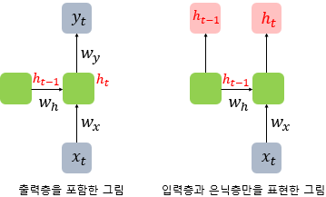

- **RNN 층은 사용자의 설정에 따라 두 가지 종류의 출력 존재**
  - **메모리 셀의 최종 시점의 은닉 상태만을 리턴하고자 한다면 (`batch_size`, `output_dim`) 크기의 2D 텐서를 리턴**
  - **메모리 셀의 각 시점(time step)의 은닉 상태값들을 모아서 전체 시퀀스를 리턴하고자 한다면 (`batch_size`, `timesteps`, output_dim) 크기의 3D 텐서를 리턴**
- **RNN 층의 `return_sequences` 매개 변수에 `True를` 설정하여 설정이 가능**

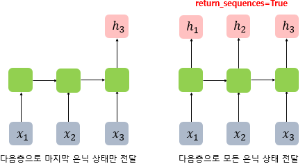

- **`time step=3`일 때, `return_sequences = True`를 설정했을 때와 그렇지 않았을 때 차이**
  - **`return_sequences=True`를 선택하면 메모리 셀이 모든 시점(time step)에 대해서 은닉 상태값을 출력**
  - **`return_sequences=False`로 선택할 경우에는 메모리 셀은 하나의 은닉 상태값만을 출력.**
  - **하나의 값은 마지막 시점(time step)의 메모리 셀의 은닉 상태값**
- **마지막 은닉 상태만 전달하도록 하면 다 대 일(many-to-one) 문제를 풀 수 있고, 모든 시점의 은닉 상태를 전달하도록 하면, 다음층에 RNN 은닉층이 하나 더 있는 경우이거나 다 대 다(many-to-many) 문제**
- **출력값이 (`batch_size`, `output_dim`) 크기의 2D 텐서일 때** : output_dim은 hidden_units의 값인 3
  - batch_size를 현 단계에서는 알 수 없으므로 (None, 3)

```python
model = Sequential()
model.add(SimpleRNN(3, input_shape=(2,10)))
# model.add(SimpleRNN(3, input_length=2, input_dim=10))와 동일함.
model.summary()
```

```
Model: "sequential"
_________________________________________________________________
 Layer (type)                Output Shape              Param #
=================================================================
 simple_rnn (SimpleRNN)      (None, 3)                 42

=================================================================
Total params: 42
Trainable params: 42
Non-trainable params: 0
_________________________________________________________________
```

- **`batch_size`를 8로 기재하면 출력의 크기가 (8, 3)**

```python
model = Sequential()
model.add(SimpleRNN(3, batch_input_shape=(8,2,10)))
model.summary()
```

```
Model: "sequential_1"
_________________________________________________________________
 Layer (type)                Output Shape              Param #
=================================================================
 simple_rnn_1 (SimpleRNN)    (8, 3)                    42

=================================================================
Total params: 42
Trainable params: 42
Non-trainable params: 0
_________________________________________________________________
```

- **`return_sequences 매개 변수에 True를 기재하여 출력값으로 batch_size timesteps output_dim`) 크기의 3D 텐서를 리턴**

```python
model = Sequential()
model.add(SimpleRNN(3, batch_input_shape=(8,2,10), return_sequences=True))
model.summary()
```

```
Model: "sequential_2"
_________________________________________________________________
 Layer (type)                Output Shape              Param #
=================================================================
 simple_rnn_2 (SimpleRNN)    (8, 2, 3)                 42

=================================================================
Total params: 42
Trainable params: 42
Non-trainable params: 0
_________________________________________________________________
```

### Numpy로 RNN구현

- 메모리 셀에서 은닉 상태를 계산하는 식

#### $h_{t} = tanh(W_{x}X_{t} + W_{h}h_{t−1} + b)$

```
hidden_state_t = 0 # 초기 은닉 상태를 0(벡터)로 초기화

for input_t in input_length: # 각 시점마다 입력을 받는다.
    output_t = tanh(input_t, hidden_state_t) # 각 시점에 대해서 입력과 은닉 상태를 가지고 연산
    hidden_state_t = output_t # 계산 결과는 현재 시점의 은닉 상태가 된다.
```

- t 시점의 은닉 상태를 `hidden_state_t라는` 변수로 선언
- 입력 데이터의 길이를 `input_length로` 선언
  - 입력 데이터의 길이는 총 시점의 수(`timesteps`)
- t 시점의 입력값을 `input_t`로 선언
- 각 메모리 셀은 각 시점마다 `input_t`와 `hidden_sate_t`(이전 상태의 은닉 상태)를 입력으로 활성화 함수인 하이퍼볼릭탄젠트 함수를 통해 현 시점의 `hidden_state_t`를 계산
- `timesteps`는 시점의 수 (자연어 처리에서는 보통 문장의 길이)
- `input_dim`은 입력의 차원 (자연어 처리에서는 보통 단어 벡터의 차원)
- `hidden_units`는 은닉 상태의 크기로 메모리 셀의 용량
  - 초기 은닉 상태는 0의 값을 가지는 벡터로 초기화
- 은닉 상태의 크기를 8로 정의하였으므로 8의 차원을 가지는 0의 값으로 구성된 벡터가 출력

```python
timesteps = 10
input_dim = 4
hidden_units = 8

# 입력에 해당되는 2D 텐서
inputs = np.random.random((timesteps, input_dim))

# 초기 은닉 상태는 0(벡터)로 초기화
hidden_state_t = np.zeros((hidden_units,))

print('초기 은닉 상태 :',hidden_state_t)
```

```
초기 은닉 상태 : [0. 0. 0. 0. 0. 0. 0. 0.]
```

- `Wx` : (은닉 상태의 크기 × 입력의 차원)
- `Wh` : (은닉 상태의 크기 × 은닉 상태의 크기)
- `b` : (은닉 상태의 크기)의 크기

```python
Wx = np.random.random((hidden_units, input_dim))  # (8, 4)크기의 2D 텐서 생성. 입력에 대한 가중치.
Wh = np.random.random((hidden_units, hidden_units)) # (8, 8)크기의 2D 텐서 생성. 은닉 상태에 대한 가중치.
b = np.random.random((hidden_units,)) # (8,)크기의 1D 텐서 생성. 이 값은 편향(bias).

print('가중치 Wx의 크기(shape) :',np.shape(Wx))
print('가중치 Wh의 크기(shape) :',np.shape(Wh))
print('편향의 크기(shape) :',np.shape(b))
```

```
가중치 Wx의 크기(shape) : (8, 4)
가중치 Wh의 크기(shape) : (8, 8)
편향의 크기(shape) : (8,)
```

```python
total_hidden_states = []

# 각 시점 별 입력값.
for input_t in inputs:

  # Wx * Xt + Wh * Ht-1 + b(bias)
  output_t = np.tanh(np.dot(Wx,input_t) + np.dot(Wh,hidden_state_t) + b)

  # 각 시점 t별 메모리 셀의 출력의 크기는 (timestep t, output_dim)
  # 각 시점의 은닉 상태의 값을 계속해서 누적
  total_hidden_states.append(list(output_t))
  hidden_state_t = output_t

# 출력 시 값을 깔끔하게 해주는 용도.
total_hidden_states = np.stack(total_hidden_states, axis = 0)

# (timesteps, output_dim)
print('모든 시점의 은닉 상태 :')
print(total_hidden_states)
```

```
모든 시점의 은닉 상태 :
[[0.77951244 0.78770024 0.82432468 0.91908954 0.86239098 0.82119966
  0.85239611 0.90641487]
 [0.99980242 0.99993124 0.99951104 0.99994965 0.99986208 0.99888069
  0.99991119 0.99973034]
 [0.99989113 0.99998724 0.99987007 0.99998246 0.99994752 0.99941109
  0.99997646 0.99994423]
 [0.99998317 0.99998923 0.99994637 0.9999961  0.99998439 0.99979501
  0.99998986 0.99996326]
 [0.99998725 0.99999515 0.99993379 0.99999842 0.99998952 0.99987684
  0.99999434 0.99998939]
 [0.99992828 0.99999158 0.99992882 0.99999332 0.99995847 0.9997233
  0.99998609 0.99996632]
 [0.99997339 0.99998411 0.99986348 0.999988   0.99996691 0.99968093
  0.9999734  0.99989873]
 [0.99993272 0.99998773 0.99991025 0.99998889 0.99995755 0.99960964
  0.99998073 0.99994362]
 [0.9999875  0.99999204 0.9999709  0.99999823 0.99998736 0.99988492
  0.99999369 0.99997575]
 [0.99996041 0.99999442 0.9999197  0.9999966  0.99995348 0.99989143
  0.99998606 0.99996725]]
```

### 깊은 순환 신경망(Deep Recurrent Neural Network)

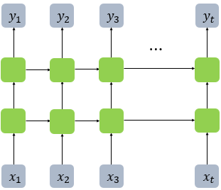

- 위의 그림은 순환 신경망에서 은닉층이 1개 더 추가되어 은닉층이 2개인 깊은(deep) 순환 신경망의 모습

```python
model = Sequential()
model.add(SimpleRNN(hidden_units, input_length=10, input_dim=5, return_sequences=True))
model.add(SimpleRNN(hidden_units, return_sequences=True))
```

- 첫번째 은닉층은 다음 은닉층이 존재하므로 **`return_sequences = True`**를 설정 $→$ 모든 시점에 대해서 은닉 상태 값을 다음 은닉층으로 전송

### 양방향 순환 신경망(Bidirectional Recurrent Neural Network)

- 양방향 순환 신경망은 시점 t에서의 출력값을 예측할 때 **이전 시점의 입력뿐만 아니라, 이후 시점의 입력 또한 예측에 기여할 수 있다는 아이디어에 기반**
- 이전과 이후의 시점 모두를 고려해서 현재 시점의 예측을 더욱 정확하게 할 수 있도록 고안된 것이 양방향 RNN

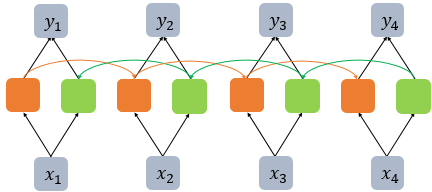

- 양방향 RNN은 하나의 출력값을 예측하기 위해 기본적으로 두 개의 메모리 셀을 사용
- **첫번째 메모리 셀은 앞 시점의 은닉 상태(Forward States) 를 전달받아 현재의 은닉 상태를 계산** (주황색)
- **두번째 메모리 셀은 뒤 시점의 은닉 상태(Backward States) 를 전달 받아 현재의 은닉 상태를 계산** (초록색)

  **즉, 입력 시퀀스를 반대 방향으로 읽는 것**
- **이 두 개의 값 모두가 현재 시점의 출력층에서 출력값을 예측하기 위해 사용**

#### `tensorflow.keras.layers.Bidirectional(layer)`

```python
from tensorflow.keras.layers import Bidirectional
```

```python
timesteps = 10
input_dim = 5

model = Sequential()
model.add(Bidirectional(SimpleRNN(hidden_units, return_sequences=True), input_shape=(timesteps, input_dim)))
model.summary()
```

```
Model: "sequential_6"
_________________________________________________________________
 Layer (type)                Output Shape              Param #
=================================================================
 bidirectional_5 (Bidirectio  (None, 10, 16)           224
 nal)

=================================================================
Total params: 224
Trainable params: 224
Non-trainable params: 0
_________________________________________________________________
```

- 양방향 RNN도 다수의 은닉층을 가질 수 있음

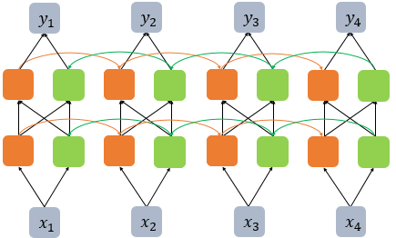

## 장단기 메모리(Long Short-Term Memory, LSTM)

### 바닐라 RNN의 한계

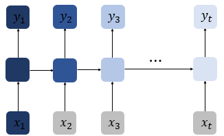

- 바닐라 RNN은 출력 결과가 이전의 계산 결과에 의존

### 바닐라 RNN의 내부 구조

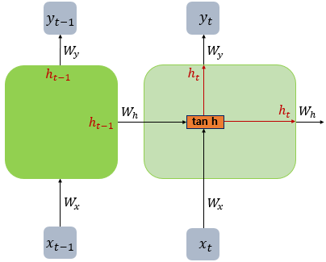

#### $h_{t} = tanh(W_{x}x_{t} + W_{h}h_{t−1} + b)$

- 바닐라 RNN은 $x_t$와 $h_{t-1}$이라는 두 개의 입력이 각각의 가중치와 곱해져서 메모리 셀의 입력됨
- 그리고 이를 하이퍼볼릭탄젠트 함수의 입력으로 사용하고, 이 값은 은닉층의 출력인 은닉 상태가 됨

### LSTM(Long Short-Term Memory)

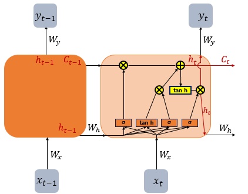

- 전통적인 RNN의 이러한 단점을 보완한 RNN의 일종을 장단기 메모리(Long Short-Term Memory)
- **LSTM은 은닉층의 메모리 셀에 입력 게이트, 망각 게이트, 출력 게이트를 추가하여 불필요한 기억을 지우고, 기억해야할 것들을 결정**

  LSTM은 은닉 상태(hidden state)를 계산하는 식이 전통적인 RNN보다 조금 더 복잡해졌으며 셀 상태(cell state)라는 값을 추가
- LSTM은 RNN과 비교하여 긴 시퀀스의 입력을 처리하는데 탁월한 성능

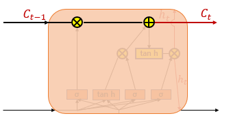

- **셀 상태 또한 은닉 상태처럼 이전 시점의 셀 상태가 다음 시점의 셀 상태를 구하기 위한 입력으로서 사용**
- 은닉 상태의 값과 셀 상태의 값을 구하기 위해서 **삭제 게이트, 입력 게이트, 출력 게이트**를 사용
  - **3개의 게이트에는 공통적으로 시그모이드 함수가 존재**
  - 시그모이드 함수를 통한 0과 1사이의 값으로 게이트를 조절

#### 입력 게이트

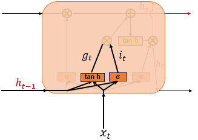

- **입력 게이트는 현재 정보를 기억하기 위한 게이트**

#### $i_{t}=σ(W_{xi}x_{t}+W_{hi}h_{t-1}+b_{i})$

- **현재 시점 t의 $x$값과 입력 게이트로 이어지는 가중치 $W_xi$

를 곱한 값과, 이전 시점 t-1의 은닉 상태 ($h_{t-1}$)가 입력 게이트로 이어지는 가중치 $W_{hi}$를 곱한 값을 더하여 시그모이드 함수를 지남**

#### $g_{t}=tanh(W_{xg}x_{t}+W_{hg}h_{t-1}+b_{g})$

- **현재 시점 t의 $x$값과 입력 게이트로 이어지는 가중치 $W_{xg}$를 곱한 값과, 이전 시점 t-1의 은닉 상태 ($h_{t-1}$)가, 입력 게이트로 이어지는 가중치 $W_{hg}$를 곱한 값을 더하여 하이퍼볼릭탄젠트 함수를 지남**
- **시그모이드 함수를 지나 0과 1사이의 값을 가지는 $i_t$과, 하이퍼볼릭탄젠트 함수를 지나 -1과 1사이의 값을 가지는 $g_t$값을 가지고 이번에 선택된 기억할 정보의 양을 결정**

#### 삭제게이트

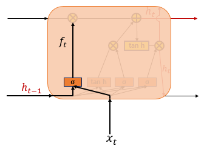

- 삭제 게이트는 기억을 삭제하기 위한 게이트

#### $f_{t}=σ(W_{xf}x_{t}+W_{hf}h_{t-1}+b_{f})$

- **현재 시점 t의 $x$값과 이전 시점 t-1의 은닉 상태 ($h_{t-1}$)가 시그모이드 함수를 지남**
- **시그모이드 함수를 통한 0과 1 사이의 값이 삭제 과정을 거친 정보의 양**
  - **0에 가까울수록 정보가 많이 삭제된 것이고 1에 가까울수록 정보를 온전히 기억한 것**
  - 이를 가지고 셀 상태를 계산

#### 셀 상태

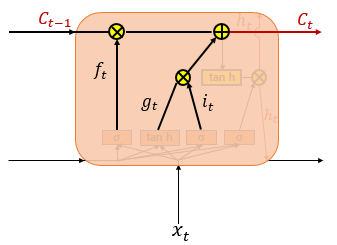

#### $C_{t}=f_{t}∘C_{t-1}+i_{t}∘g_{t}$

- **입력 게이트에서 구한 $i_t$, $g_t$의 값에 대해서 원소별 곱(entrywise product)을 진행**
  - 같은 크기의 두 행렬이 있을 때 같은 위치의 성분끼리 곱 $→$ **선택된 기억할 값**
- **입력 게이트에서 선택된 기억을, 삭제 게이트의 결과값과 더함 $→$ 현재 시점 t의 셀 상태**
  - 이 값은 다음 t+1 시점의 LSTM 셀로 전달

#### 삭제 게이트와 입력 게이트의 영향력

- **만약 삭제 게이트의 출력값인 $f_t$가 0이 된다면, 이전 시점의 셀 상태의 값인 $C_{t-1}$은 현재 시점의 셀 상태의 값을 결정하기 위한 영향력이 0이 되면서, 오직 입력 게이트의 결과만이 현재 시점의 셀 상태의 값 $C_t$을 결정**
  - 이는 삭제 게이트가 완전히 닫히고 입력 게이트를 연 상태를 의미
- **입력 게이트의 $i_t$값을 0이라고 한다면, 현재 시점의 셀 상태의 값 $C_t$는 오직 이전 시점의 셀 상태의 값 $C_{t-1}$의 값에만 의존**
- 이는 입력 게이트를 완전히 닫고 삭제 게이트만을 연 상태를 의미

#### 결과적으로 삭제 게이트는 이전 시점의 입력을 얼마나 반영할지를 의미

#### 입력 게이트는 현재 시점의 입력을 얼마나 반영할지를 결정

### 출력 게이트와 은닉 상태

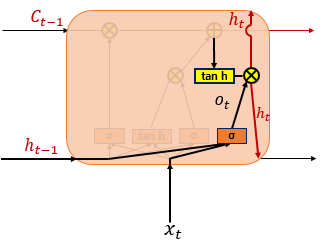

#### $o_{t}=σ(W_{xo}x_{t}+W_{ho}h_{t-1}+b_{o})$

- **출력 게이트는 현재 시점 t의 $x$값과, 이전 시점 t-1의 은닉 상태가 시그모이드 함수를 지난 값**
- 현재 시점 t의 은닉 상태를 결정하는데 사용

#### $h_{t}=o_{t}∘tanh(c_{t})$

- **셀 상태의 값이 하이퍼볼릭탄젠트 함수를 지나 -1과 1사이의 값이 되고, 출력 게이트의 값과 연산되면서,**

  **값이 걸러지는 효과가 발생하여 은닉 상태가 됨**
- **은닉 상태의 값은 출력층으로도 향함**

## 게이트 순환 유닛(Gated Recurrent Unit, GRU)

- GRU(Gated Recurrent Unit)는 2014년 뉴욕대학교 조경현 교수의 논문에서 제안
- **GRU는 LSTM의 장기 의존성 문제에 대한 해결책을 유지하면서, 은닉 상태를 업데이트하는 계산을 감소**
  - GRU는 성능은 LSTM과 유사하면서 복잡했던 LSTM의 구조를 간단화

### GRU(Gated Recurrent Unit)

- **GRU에서는 업데이트 게이트와 리셋 게이트 두 가지 게이트만이 존재**
- GRU는 LSTM보다 학습 속도가 빠르다고 알려져있지만 여러 평가에서 GRU는 LSTM과 비슷한 성능

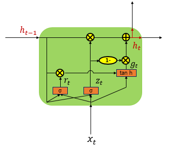

#### $r_{t}=σ(W_{xr}x_{t}+W_{hr}h_{t-1}+b_{r})$

#### $z_{t}=σ(W_{xz}x_{t}+W_{hz}h_{t-1}+b_{z})$

#### $g_{t}=tanh(W_{hg}(r_{t}∘h_{t-1})+W_{xg}x_{t}+b_{g})$

#### $h_{t}=(1-z_{t})∘g_{t}+z_{t}∘h_{t-1}$

- GRU와 LSTM 중 어떤 것이 모델의 성능면에서 더 낫다라고 단정지어 말할 수 없으며,

  기존에 LSTM을 사용하면서 최적의 하이퍼파라미터를 찾아낸 상황이라면 굳이 GRU로 바꿔서 사용할 필요는 없음
- 경험적으로 데이터 양이 적을 때는 매개 변수의 양이 적은 GRU가 조금 더 낫고,

  데이터 양이 더 많으면 LSTM이 더 낫다고함

## 케라스의 SimpleRNN과 LSTM

#### 임의의 입력 생성

```python
import numpy as np
import tensorflow as tf
from tensorflow.keras.layers import SimpleRNN, LSTM, Bidirectional
```

- 단어 벡터의 차원은 5이고, 문장의 길이가 4인 경우를 가정

  **다시 말해 4번의 시점(timesteps)이 존재하고, 각 시점마다 5차원의 단어 벡터가 입력으로 사용**

```python
train_X = [[0.1, 4.2, 1.5, 1.1, 2.8],
           [1.0, 3.1, 2.5, 0.7, 1.1],
           [0.3, 2.1, 1.5, 2.1, 0.1],
           [2.2, 1.4, 0.5, 0.9, 1.1]]
print(np.shape(train_X))
```

```
(4, 5)
```

- 하지만 RNN은 2D 텐서가 아니라 3D 텐서를 입력을 받음 $→$ 2D 텐서를 3D 텐서로 변경
  - 배치 크기 1을 추가
  - (batch_size, `timesteps`, `input_dim`)에 해당되는 (1, 4, 5)의 크기를 가지는 3D 텐서가 생성
  - `batch_size`는 한 번에 RNN이 학습하는 데이터의 양을 의미

```python
train_X = [[[0.1, 4.2, 1.5, 1.1, 2.8],
            [1.0, 3.1, 2.5, 0.7, 1.1],
            [0.3, 2.1, 1.5, 2.1, 0.1],
            [2.2, 1.4, 0.5, 0.9, 1.1]]]
train_X = np.array(train_X, dtype=np.float32)
print(train_X.shape)
```

```
(1, 4, 5)
```

### SimpleRNN

#### `tensorflow.keras.layers.SimpleRNN()`

#### `return_sequence=False`로 설정 $→$ SimpleRNN은 마지막 시점의 은닉 상태만 출력

```python
rnn = SimpleRNN(3)
# rnn = SimpleRNN(3, return_sequences=False, return_state=False)와 동일.
hidden_state = rnn(train_X)

print('hidden state : {}, shape: {}'.format(hidden_state, hidden_state.shape))
```

```
hidden state : [[-0.9741143 -0.9355809 -0.7463395]], shape: (1, 3)
```

#### `return_sequence=True`로 설정 $→$ 모든 시점의 은닉 상태를 출력

- (1, 4, 3) 크기의 텐서가 출력
- (1, 4, 5)의 크기를 가지는 3D 텐서였고, 그 중 4가 시점(timesteps)에 해당하는 값이므로,

  **모든 시점에 대해서 은닉 상태의 값을 출력하여 (1, 4, 3) 크기의 텐서를 출력**

```python
rnn = SimpleRNN(3, return_sequences=True)
hidden_states = rnn(train_X)

print('hidden states : {}, shape: {}'.format(hidden_states, hidden_states.shape))
```

```
hidden states : [[[ 0.46391347 -0.23038094 -0.2763267 ]
  [ 0.5126749   0.43301442 -0.9704439 ]
  [ 0.6264551  -0.9082007  -0.94755834]
  [ 0.8350477   0.27962142 -0.7766052 ]]], shape: (1, 4, 3)
```

#### **`return_state`가 `True`일 경우에는 `return_sequences`의 True/False 여부와 상관없이 마지막 시점의 은닉 상태를 출력**

- **`return_sequences`가 `True`이면서, `return_state`를 `True`로 할 경우 SimpleRNN은 두 개의 출력을 리턴**
  - 첫번째 출력은 `return_sequences=True`로 인한 출력으로 모든 시점의 은닉 상태
  - 두번째 출력은 `return_state=True`로 인한 출력으로 마지막 시점의 은닉 상태

```python
rnn = SimpleRNN(3, return_sequences=True, return_state=True)
hidden_states, last_state = rnn(train_X)

print('hidden states : {}, shape: {}'.format(hidden_states, hidden_states.shape), end='\n\n')
print('last hidden state : {}, shape: {}'.format(last_state, last_state.shape))
```

```
hidden states : [[[-0.881399    0.9964273   0.9999715 ]
  [-0.28497222 -0.18911481  0.9682448 ]
  [-0.86571985 -0.8554715   0.97805667]
  [-0.99801284  0.17286034 -0.24704449]]], shape: (1, 4, 3)

last hidden state : [[-0.99801284  0.17286034 -0.24704449]], shape: (1, 3)
```

#### `return_sequences`는 `False`인데, `retun_state`가 `True`인 경우

- 두 개의 출력 모두 마지막 시점의 은닉 상태를 출력

```python
rnn = SimpleRNN(3, return_sequences=False, return_state=True)
hidden_state, last_state = rnn(train_X)

print('hidden state : {}, shape: {}'.format(hidden_state, hidden_state.shape), end='\n\n')
print('last hidden state : {}, shape: {}'.format(last_state, last_state.shape))
```

```
hidden state : [[ 0.7493904  0.7313836 -0.9757516]], shape: (1, 3)

last hidden state : [[ 0.7493904  0.7313836 -0.9757516]], shape: (1, 3)
```

### LSTM

#### `return_sequences`는 `False`인데, `retun_state`가 `True`인 경우

- 세 개의 결과를 반환
  - **`return_sequences`가 `False`이므로 첫번째 결과는 마지막 시점의 은닉 상태**
  - **`return_state`를 `True`로 둔 경우에는 마지막 시점의 은닉 상태뿐만 아니라 셀 상태까지 반환**

```python
lstm = LSTM(3, return_sequences=False, return_state=True)
hidden_state, last_state, last_cell_state = lstm(train_X)

print('hidden state : {}, shape: {}'.format(hidden_state, hidden_state.shape), end='\n\n')
print('last hidden state : {}, shape: {}'.format(last_state, last_state.shape), end='\n\n')
print('last cell state : {}, shape: {}'.format(last_cell_state, last_cell_state.shape), end='\n\n')
```

```
hidden state : [[ 0.11732011  0.3588194  -0.18761653]], shape: (1, 3)

last hidden state : [[ 0.11732011  0.3588194  -0.18761653]], shape: (1, 3)

last cell state : [[ 0.39968514  0.6954052  -0.9835489 ]], shape: (1, 3)
```

#### `return_sequences`는 `True`, `retun_state`가 `True`인 경우

- `return_state`가 `True`이므로 두번째 출력값이 마지막 은닉 상태,
- 세번째 출력값이 마지막 셀 상태인 것은 변함없지만 `return_sequences`가 `True`이므로 첫번째 출력값은 모든 시점의 은닉 상태가 출력

```python
lstm = LSTM(3, return_sequences=True, return_state=True)
hidden_states, last_hidden_state, last_cell_state = lstm(train_X)

print('hidden states : {}, shape: {}'.format(hidden_states, hidden_states.shape), end='\n\n')
print('last hidden state : {}, shape: {}'.format(last_hidden_state, last_hidden_state.shape), end='\n\n')
print('last cell state : {}, shape: {}'.format(last_cell_state, last_cell_state.shape), end='\n\n')
```

```
hidden states : [[[ 0.41945407  0.15474255  0.58540106]
  [ 0.74142075  0.20514093  0.5136904 ]
  [ 0.7977318  -0.05289869  0.5710511 ]
  [ 0.72348046 -0.424805    0.30673727]]], shape: (1, 4, 3)

last hidden state : [[ 0.72348046 -0.424805    0.30673727]], shape: (1, 3)

last cell state : [[ 1.5532852 -0.7367273  0.9112263]], shape: (1, 3)
```

### Bidirectional(LSTM)

#### 출력되는 은닉 상태의 값을 고정

```python
k_init = tf.keras.initializers.Constant(value=0.1)
b_init = tf.keras.initializers.Constant(value=0)
r_init = tf.keras.initializers.Constant(value=0.1)
```

#### `return_sequences`는 `False`인데, `retun_state`가 `True`인 경우

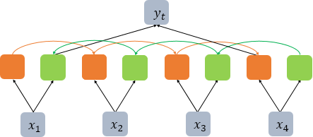

- 5개의 값을 반환
- `return_state`가 `True`인 경우에는 정방향 LSTM의 은닉 상태와 셀 상태, 역방향 LSTM의 은닉 상태와 셀 상태 4가지를 반환
- 셀 상태는 각각 `forward_c`와 `backward_c`에 저장만 하고 출력하지 않음
- **`return_sequences`가 `False`인 경우, 정방향 LSTM의 마지막 시점의 은닉 상태와 역방향 LSTM의 첫번째 시점의 은닉 상태가 연결된 채 반환**
- **`return_state`가 `True`인 경우 `forward_h`와 `backward_h`는 각각 정방향 LSTM의 마지막 시점의 은닉 상태와 역방향 LSTM의 첫번째 시점의 은닉 상태값**

  **그리고 이 두 값을 연결한 값이 `hidden_states`에 출력되는 값** **$→$ `hidden_state`의 크기가 (1, 6)**

```python
bilstm = Bidirectional(LSTM(3, return_sequences=False, return_state=True, \
                            kernel_initializer=k_init, bias_initializer=b_init, recurrent_initializer=r_init))
hidden_states, forward_h, forward_c, backward_h, backward_c = bilstm(train_X)

print('hidden states : {}, shape: {}'.format(hidden_states, hidden_states.shape), end='\n\n')
print('forward state : {}, shape: {}'.format(forward_h, forward_h.shape), end='\n\n')
print('backward state : {}, shape: {}'.format(backward_h, backward_h.shape), end='\n\n')
```

```
hidden states : [[0.6303139  0.6303139  0.6303139  0.70387346 0.70387346 0.70387346]], shape: (1, 6)

forward state : [[0.6303139 0.6303139 0.6303139]], shape: (1, 3)

backward state : [[0.70387346 0.70387346 0.70387346]], shape: (1, 3)
```

#### `return_sequences`는 `True`인데, `retun_state`가 `True`인 경우

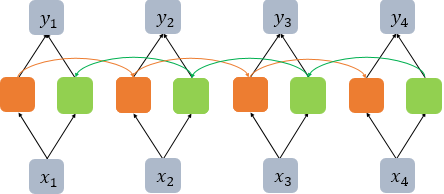

- `hidden states`의 출력값에서는 모든 시점의 은닉 상태가 출력
- **역방향 LSTM의 첫번째 시점의 은닉 상태는 더 이상 정방향 LSTM의 마지막 시점의 은닉 상태와 연결되는 것이 아니라 정방향 LSTM의 첫번째 시점의 은닉 상태와 연결**

```python
bilstm = Bidirectional(LSTM(3, return_sequences=True, return_state=True, \
                            kernel_initializer=k_init, bias_initializer=b_init, recurrent_initializer=r_init))
hidden_states, forward_h, forward_c, backward_h, backward_c = bilstm(train_X)
```

```python
print('hidden states : {}, shape: {}'.format(hidden_states, hidden_states.shape), end='\n\n')
print('forward state : {}, shape: {}'.format(forward_h, forward_h.shape), end='\n\n')
print('backward state : {}, shape: {}'.format(backward_h, backward_h.shape), end='\n\n')
```

```
hidden states : [[[0.35906476 0.35906476 0.35906476 0.70387346 0.70387346 0.70387346]
  [0.5511133  0.5511133  0.5511133  0.5886358  0.5886358  0.5886358 ]
  [0.5911575  0.5911575  0.5911575  0.39516988 0.39516988 0.39516988]
  [0.6303139  0.6303139  0.6303139  0.2194224  0.2194224  0.2194224 ]]], shape: (1, 4, 6)

forward state : [[0.6303139 0.6303139 0.6303139]], shape: (1, 3)

backward state : [[0.70387346 0.70387346 0.70387346]], shape: (1, 3)
```